```python
import numpy as np
import seaborn as sns
import scipy.stats as stats
%pylab inline
```

# Теорвер дз. 29.03.17

## Задача 7

На улице стоит продавец газет. Проходящий мимо прохожий покупает газету с вероятностью $p = \frac{1}{4}$. Найти распределение количества прошедших мимо прохожих, если у продавца купили $c = 100$ газет.

Нужно выбрать правильную случайную величину и применить ЦПТ.

Будем считать, что прохожие независимы и проходят мимо продавца в разные моменты времени(одновременно не подходят).

Определим случайную величину $\xi_1$ такую, что $P(\xi_1^{-1}(t))$ - это вероятность того, что среди $t$ последовательных прохожих первые $t-1$ не купят газету, а $t$-ый - купит. Данное определение соответствует определению геометрического распределения.

Чтобы воспользоваться ЦПТ нам нужно посчитать матожидание и дисперсию.

$$E(\xi_1) = \sum_{i=1}^{\infty} tq^{t-1}p = p\sum_{i=1}^{\infty} tq^{t-1} = p \sum_{i=1}^{\infty} (q^t)_q' = p (\sum_{i=1}^{\infty} q^t)_q'= p (\frac{q}{1 - q})_q' = p (\frac{1}{(1 - q)^2}) = \frac{1}{p}$$

```python
def xi_expectation(p, iterations=10000):
    q = 1 - p
    return sum([t * q**(t - 1) * p for t in range(1, iterations)])
print('Approximated expectation: {}'.format(xi_expectation(0.25)))
print('Expected expectation: {}'.format(1.0 / 0.25))
```

```
Approximated expectation: 4.0
Expected expectation: 4.0
```

$$D(\xi_1) = E(\xi_1^2) - E(\xi_1)^2 = \sum_{i=1}^{\infty} t^2 q^{t-1}p - \frac{1}{p^2} = \sum_{i=1}^{\infty} t(t+1) q^{t-1}p - \sum_{i=1}^{\infty}t q^{t-1}p - \frac{1}{p^2} = p(\sum_{i=1}^{\infty} q^{t+1})_q'' - E(\xi_1) - \frac{1}{p^2} = p(\frac{1}{(1 - q)^2})_q' - \frac{1}{p} - \frac{1}{p^2} = p(\frac{2}{(1 - q)^3}) - \frac{1}{p} - \frac{1}{p^2} = \frac{2}{p^2} - \frac{1}{p} - \frac{1}{p^2} = \frac{1 - p}{p^2}$$

```python
def xi_variance(p, iterations=100000):
    q = 1 - p
    return sum([(t - 1 / p)**2 * q**(t - 1) * p for t in range(1, iterations)])
print('Approximated vairance: {}'.format(xi_variance(0.25)))
print('Expected vairance: {}'.format((1 - 0.25) / (0.25**2)))
```

```
Approximated vairance: 12.0
Expected vairance: 12.0
```

Значит нам нужно посчитать сумму независимых одинаково распределенных случайных величин с $\mu = \frac{1}{p}$ и $\sigma = \sqrt \frac{1 - p}{p^2}$.

Из ЦПТ следует, что $$\frac{\sum_{i=1}^{n} \xi_1^i - n\mu}{\sigma \sqrt n} = \mathcal{N}(0, 1)$$

Будем считать, что нужно посчитать количество прошедших мимо прохожих **ровно** в тот момент, когда у продавца купили сотую газету. Тогда нам нужно просто получить оценку на $\sum_{i=1}^{n} \xi_1^i = n \mu + \sigma \sqrt n\mathcal{N}(0, 1)$

```python
def sample_newspapers(p, newspapers=100):
    count = 0
    while newspapers > 0:
        newspapers -= np.random.binomial(1, p)
        count += 1
    return count
```

```python
def draw_sample_newspapers_density(p, newspapers=100, samples=1000):
    sns.distplot([sample_newspapers(p, newspapers) for _ in range(samples)], norm_hist=True)

def draw_expected_newspapers_density(p, newspapers=100, samples=1000):
    pdf = lambda x: stats.norm.pdf(x, loc=newspapers * 1 / p, scale=np.sqrt(newspapers * (1 - p) / p**2))
    xs = np.linspace(200, 600, 400)
    ys = [pdf(x) for x in xs]
    plot(xs, ys)
```

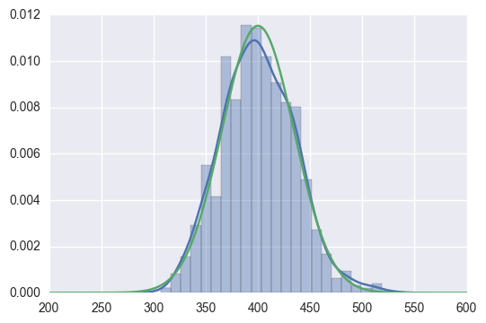

```python
draw_sample_newspapers_density(0.25, 100, 1000)
draw_expected_newspapers_density(0.25, 100, 1000)
```

Значит искомое распределение действительно достаточно точно совпадает с $\mathcal{N}(n\mu, \sigma \sqrt n)$.

## Задача 8

Книга объемом $n = 500$ страниц содержит $c = 50$ опечаток. Оценить вероятность того, что на случайной странице книги будет не менее $k = 3$ опечаток.

Будем считать, что опечатки распределены по страницам равномерно и независимо друг от друга (что достаточно сильное предположение, но что делать). Тогда можно рассмотреть фиксированную страницу и считать, что вероятность появления на ней одной опечатки есть Бернуллиевская случайная величина $\xi$ с вероятностью успеха равной $p = \frac{1}{n}$

Параметры $\xi$:

- $E(\xi) = p = \frac{1}{n} = \frac{1}{500}$
- $D(\xi) = (1 - p)^2 p + p^2 (1 - p) = p (1 - p) = pq = \frac{499}{500^2} = \sigma^2$

Значит сумму величин $\sum_{i=1}^{c} \xi_i$ можно приблизить нормальным распределением $\mathcal{N}(cp, \sigma \sqrt c) = \mathcal{N}(\frac{50}{500}, \frac{\sqrt{499 * 50}}{500})$

```python
def sample_typos(p, c=50):
    return np.random.binomial(c, p)
```

```python
def draw_sample_typos_density(p, c=50, samples=10000):
    data = [sample_typos(p, c) for _ in range(samples)]
    hist(data, weights=np.ones_like(data) / len(data))

def draw_expected_typos_density_norm(p, c=50):
    pdf = lambda x: stats.norm.pdf(x, loc=c * p, scale=np.sqrt(c * p * (1 - p)))
    xs = np.linspace(0, 3, 1000)
    ys = [pdf(x) for x in xs]
    plot(xs, ys)
```

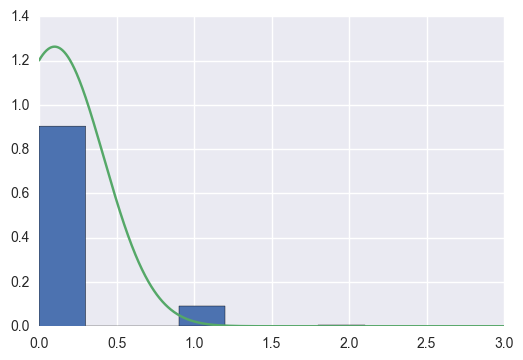

```python
draw_sample_typos_density(1.0 / 500, 50, 100000)
draw_expected_typos_density_norm(1.0 / 500)
```

В принципе нормальное распределение в некоторой степени угадывает форму распределения, однако расхождение уже при $k=3$ очень велико.

```python
def sample_typos_density(k, p, c=50, samples=1000000):
    data = np.array([sample_typos(p, c) for _ in range(samples)])
    return np.sum(data >= k) / samples
def estimate_typos_density_norm(k, p, c=50):
    return 1 - stats.norm.cdf(k, loc=c * p, scale=np.sqrt(c * p * (1 - p)))

typos = 3
print('Approximated probability of >= {} typos: {}'.format(typos, sample_typos_density(typos, 1.0 / 500)))
print('Expected probability of >= {} typos: {}'.format(typos, estimate_typos_density_norm(typos, 1.0 / 500)))
```

```
Approximated probability of >= 3 typos: 0.000127
Expected probability of >= 3 typos: 0.0
```

Можно оценить ошибку нашего приближения с помощью неравенства Берри-Эссеена:

- $E(|\xi - E(\xi)|^3) = E(|\xi - p|^3) = (1 - p)^3p + p^3(1 - p) = p(1 - p)((1 - p)^2 + p^2) = \tau$, при $p = \frac{1}{500}, \tau \approx 0.002$

Тогда погрешность оценки $|F_{\xi}(x) - \mathcal{N}(cp, \sigma \sqrt c)| \leq \frac{C\tau}{\sigma^3 \sqrt n} \approx 1.5$ Такая оценка крайне бесполезна, т.к. порядок нашей вероятности в разы меньше, чем значение оценки. Также видно, что хоть оценка и грубая, но результат полученный с помощью приближения нормальным распределением также малоинформативаен.

```python
p = 1.0 / 500.0
tau = p * (1 - p) * ((1 - p)**2 + p**2)
delta = 0.4784 * tau / pow((p * (1 - p)), 1.5) / np.sqrt(50)
print('Tau: {}, delta: {}'.format(tau, delta))
```

```
Tau: 0.001988031968, delta: 1.5083034591290696
```

Известный факт, что при большом количестве испытаний $n$ и малой вероятности успеха $p$, биномиальное распределение стремится к распределению Пуассона с параметром $\lambda = np$ (видно, что в общем случае это неверно, что легко заметить сравнив дисперсии: $np \neq npq$, однако при $p \rightarrow 0, q \rightarrow 1 \Rightarrow npq \rightarrow np$).

Значит наше распределение можно приблизить распределением Пуассона: $P(\xi = k) = \frac{\lambda^k e^{-\lambda}}{k!}$

```python
def draw_expected_typos_density_poisson(p, c=50):
    pmf = lambda k: stats.poisson.pmf(k, c * p)
    xs = np.linspace(0, 3, 4)
    ys = [pmf(x) for x in xs]
    plot(xs, ys)
```

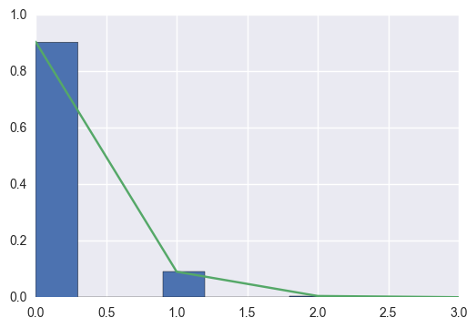

```python
draw_sample_typos_density(1.0 / 500, 50, 100000)
draw_expected_typos_density_poisson(1.0 / 500)
```

```python
def estimate_typos_density_poisson(k, p, c=50):
    return 1 - stats.poisson.cdf(k - 1, c * p)

typos = 3
print('Approximated probability of {} typos: {}'.format(typos, sample_typos_density(typos, 1.0 / 500)))
print('Expected probability of {} typos: {}'.format(typos, estimate_typos_density_poisson(typos, 1.0 / 500)))
```

```
Approximated probability of 3 typos: 0.000147
Expected probability of 3 typos: 0.00015465307026463204
```

Видно, что оценка Пуассона близка к реальной и является хорошим приближением в нашем случае.

Чтобы узнать теоретическую оценку приближения воспользуемся [теоремой Ле Камма](https://en.wikipedia.org/wiki/Le_Cam%27s_theorem)

Обозначим $\sum_{i=1}^n \xi_i = S_n$, тогда $$\sum_{k=0}^{\infty} | Pr(S_n = k) - \frac{\lambda^k e^{-\lambda}}{k!}| < 2np^2 = \Delta$$

Значит отклонение не превосходит $\Delta = 2 * 500 * \frac{1}{500^2} = 0.004$, что в разы лучше чем оценка для нормального распределения, однако применение такой оценки в случае $k=3$ не дает хороших результатов (погрешность на порядок больше значения вероятности).

## Задача 9

Пример последовательности независимых случайных величин, принимающих три значения с нулевым матожиданием и единичной дисперсией, для которых не выполняется утверждение ЦПТ.

В качестве примера такой последовательности возьмем следующие случайные величины:

$$X_i = \left\{ \begin{array}{ll} \frac{1}{i^2}, \textit{с вероятностью } \frac{i^4}{i^4 + 1}\\ -i^2, \textit{с вероятностью }\frac{1}{i^4+1}\\ \end{array} \right. $$

- Матожидание такой случайной величины равно $E(X_i) = \frac{1}{i^2} \frac{i^4}{i^4 + 1} - i^2 \frac{1}{i^4 + 1}= \frac{i^2}{i^4 + 1} - \frac{i^2}{i^4 + 1} = 0$
- Дисперсия $D(X_i) = \frac{1}{i^4} \frac{i^4}{i^4 + 1} + i^4 \frac{1}{i^4 + 1} = \frac{i^4 + 1}{i^4 + 1} = 1$

Однако также ясно, что сумма $n$ таких случайных величин не превосходит $\sum_{i=1}^{\infty} \frac{1}{i^2} < 2$, значит на луче $(2, +\infty)$ функция распределения равна $1$, что явно расходится с нормальным распределением.

## Задача 10

Стрелок попадает по мишени со следующими вероятностями:

| 10 | 9 | 8 | 7 | 6 |
| --- | --- | --- | --- | --- |
| 0.5 | 0.3 | 0.1 | 0.05 | 0.05 |

Какова вероятность, что после $n = 100$ выстрелов, он набрал больше $score_1 = 980$ очков ($score_2 = 950$)?

Можно считать что выстрелы независимы и распределены так, как дано в условии. Посчитаем матожидание и дисперсию:

```python
def expectation_variance(discrete_values):
    expectation = sum([value * prob for value, prob in discrete_values.items()])
    variance = sum([(value - expectation) ** 2 * prob for value, prob in discrete_values.items()])
    return expectation, variance
```

```python
weights = {10:0.5, 9:0.3, 8:0.1, 7:0.05, 6:0.05}
expectation, variance = expectation_variance(weights)
print('Expectation: {}, variance: {}, std: {}'.format(expectation, variance, np.sqrt(variance)))
```

```
Expectation: 9.15, variance: 1.2275, std: 1.107925990308017
```

Значит можно приблизить нашу сумму распределений нормальным с параметрами $\mathcal{N}(100 * 9.15, 10 * 1.108) = \mathcal{N}(915, 11.08)$

Осталось узнать значение функции нормального распределения в соответствующих точках.

```python
def sample_scores(n, weights, samples=10000):
    return [sum(np.random.choice(list(weights.keys()), n, p=list(weights.values()))) for _ in range(samples)]

def sample_score_probability(score, n, weights, samples=10000):
    scores = np.array(sample_scores(n, weights, samples))
    return 1.0 * np.sum(scores >= score) / len(scores)

def get_score_probability(score, expectation, variance):
    return 1 - stats.norm.cdf(score, loc=expectation, scale=variance)

shoots = 100
sum_expectation = expectation * shoots
sum_variance = np.sqrt(variance * shoots)
for score in [980, 950, 900]:
    score_expected = get_score_probability(score, sum_expectation, sum_variance)
    score_approximated = sample_score_probability(score, shoots, weights)
    print('Expected probability of score >= {}: {}'.format(score, score_expected))
    print('Approximated probability of score >= {}: {}'.format(score, score_approximated))
```

```
Expected probability of score >= 980: 2.221190897877534e-09
Approximated probability of score >= 980: 0.0
Expected probability of score >= 950: 0.0007914059730048661
Approximated probability of score >= 950: 0.0005
Expected probability of score >= 900: 0.9121128344665674
Approximated probability of score >= 900: 0.9139
```

Для слишком больших значений $score$ сложно оценить точность приближения, т.к. вероятность действительно достаточно маленькая, а симуляция занимает много времени. Однако оценка выглядит правдоподобно и можно считать, что ответ на задачу:

- **>=980** — $2*10^{-9}$
- **>=950** — $8*10^{-4} = 0.08\%$

Можно опять воспользоваться неравенством Берри-Эссеена, чтобы оценить погрешность с теоретической точки зрения:

```python
def calculate_moment(order, discrete_values):
    expectation = sum([value * prob for value, prob in discrete_values.items()])
    moment = sum([np.abs(value - expectation) ** order * prob for value, prob in discrete_values.items()])
    return moment
tau = calculate_moment(3, weights)
delta = 0.4784 * tau / pow(variance, 1.5) / np.sqrt(shoots)
print('Tau: {}, delta: {}'.format(tau, delta))
```

```
Tau: 2.5198750000000008, delta: 0.0886416675762543
```

Т.е. точность нашей оценки $\Delta = \frac{C \tau}{\sigma^3 \sqrt n} = 0.09$

## Задача 11

Известна выбора $X_1, X_2, \cdots, X_n \sim U[0, \theta], \theta > 0$.

Пусть $$\theta_1 = 2 \frac{\sum_{i=1}^n X_i}{n}, \theta_2 = \max_{i=1}^n X_i$$

Нужно доказать, что оценка $\theta_1$ является асимптотически нормальной оценкой для $\theta$, а $\theta_2$ — нет.

Определение [нормальной асимптотической оценки](https://ru.wikipedia.org/wiki/%D0%9D%D0%B5%D1%80%D0%B0%D0%B2%D0%B5%D0%BD%D1%81%D1%82%D0%B2%D0%BE_%D0%91%D0%B5%D1%80%D1%80%D0%B8_%E2%80%94_%D0%AD%D1%81%D1%81%D0%B5%D0%B5%D0%BD%D0%B0):

Оценка является асимптотически нормальной, если $$\frac{\sqrt n (\theta_i - \theta)}{\sigma(\theta)} \rightarrow \mathcal{N}(0, 1)$$ (имеется в виду сходимость по распределению), где $\sigma(\theta)$ - характеристика нашей оценки.

Тогда несложно доказать, что $\theta_1$ является асимптотически нормальной оценкой:

$$\frac{\sqrt n (2 \frac{\sum_{i=1}^n X_i}{n} - \theta)}{\sigma(\theta)} = \frac{\frac{\sqrt n}{n} (2 \sum_{i=1}^n X_i - n\theta)}{\sigma(\theta)} = \frac{2 \sum_{i=1}^n X_i - n\theta}{\sigma(\theta) \sqrt n}$$

Из утверждения ЦПТ следует, что при $\sigma^2(\theta) = D(2 \sum X_i) = 4(D(X_1) + \cdots + D(X_n)) = \frac{4 \theta^2}{12} = \frac{\theta^2}{3}$ данная случайная величина стремится к $\mathcal{N}(0, 1)$.

Чтобы доказать, что $\theta_2$ не является асимптотически нормальной оценкой, рассмотрим для начала функцию распределения максимума $n$ равномерно распределенных случайных величин. Несложно понять, что $$F_n(x) = P\{ \omega \mid max_{\omega} X_i \le x\} = \prod P\{ \omega \mid X_i(\omega) \le x\} = F(x)^n = (\frac{x}{\theta})^n$$

Нам нужно показать, что не существует такое $\sigma(\theta)$, для которого $$(1 + \frac{x\sigma}{\theta \sqrt n})^n \rightarrow \mathcal{N}(0, 1)(x)$$

Можно воспользоваться вторым замечательным пределом, чтобы привести функцию к более нормальному виду:

$$(1 + \frac{x\sigma}{\theta \sqrt n})^n = (1 + \frac{x\sigma}{\theta \sqrt n})^{\sqrt n * \sqrt n} = e^{\frac{x\sigma}{\theta} \sqrt n}$$

Причем данная такому значения функция распределения равна на отрезке $[-\frac{\theta \sqrt n}{\sigma}; 0]$, а на луче $(0, +\infty)$ равна $1 \rightarrow$ она не сходится к $\mathcal{N}(0, 1)$

```python
def draw_average_estimation(theta, samples=100):
    xs = np.arange(0, samples)
    r = [np.random.uniform(high=theta) for _ in xs]
    ys = [2 * np.average(r[:i + 1]) for i in range(len(xs))]
    plot(xs, ys)

def draw_max_estimation(theta, samples=100):
    xs = np.arange(0, samples)
    r = [np.random.uniform(high=theta) for _ in xs]
    ys = [np.max(r[:i + 1]) for i in range(len(xs))]
    plot(xs, ys)
```

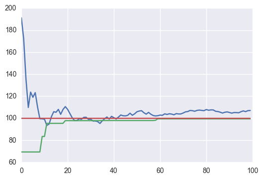

```python
theta = 100
draw_average_estimation(theta)
draw_max_estimation(theta)
plot(np.arange(0, 100), [theta for _ in range(len(np.arange(0, 100)))])
```

Видно, что несмотря на то, что оценка через максимум не является асимптотически нормальной, она очень устойчива и быстро сходится к параметру $\theta$, что нельзя сказать про оценку через удвоенное выборочное среденее.

## Задача 12

Задана область $B$ в области трехмерного пространства $A$. Методом Монте-Карло считают объем области $B$, бросая случайные точки в области $A$ и приближая объем случайной величиной $Y_n = \frac{1}{n} \sum_{i=1}^n 1_B(x_i)$. Определить, чему равно $E Y_n, D Y_n$. Найти при $n \rightarrow \infty$ предельное распределение для $\sqrt n (Y_n - Y)$, где $Y$ — объем области $B$. Оценить погрешность. Оценить в случае если $B$ имеет малый объем.

Наша случайная величина $\xi_i$ — это обычная Бернуллиевская случайная величина, с вероятностью успеха $p = V(B)$ и $q = 1 - V(B)$.

Характеристики $\xi$:

- $E(\xi) = p = V(B)$
- $D(\xi) = pq = V(B)(1 - V(B))$

Тогда несложно посчитать матожидание и дисперсию $Y_n$:

- $E(Y_n) = \frac{1}{n}(E(\xi_1) + \cdots + E(\xi_n)) = \frac{1}{n} nV(B) = V(B)$
- $D(Y_n) = \frac{1}{n^2}(D(\xi_1) + \cdots + D(\xi_n)) = \frac{D(\xi)}{n} = \frac{V(B)(1 - V(B))}{n}$

Чтобы найти предельное распределение модифицируем выражение: $$\sqrt n (Y_n - V(B)) = \sqrt n (\frac{1}{n} \sum_{i=1}^n \xi_i - V(B)) = \frac{\sqrt n}{n} (\sum_{i=1}^n \xi_i - nV(B)) = \frac{\sum_{i=1}^n \xi_i - nV(B)}{\sqrt n} = \mathcal{N}(0, \sqrt{D(Y_n)})$$

Где последний переход является следствием ЦПТ. Т.к. дисперсия уменьшается при увеличении $n$, то в пределе нормальное распределение вырождается в распределение константной случайной величины равной $0$.

Оценить точность приближения можно используя неравенство Берри-Эссеена. Для этого нужно посчитать

- $\tau = E(|\xi - E(\xi)|^3) = (1 - p)^3p + p^3(1 - p) = p(1 - p)(p^2 + (1 - p)^2)$

А значит метод Монте-Карло оценивает объем фигуры с точностью $\frac{C\tau}{\sigma^3 \sqrt n} = \frac{Cp(1 - p)(p^2 + (1 - p)^2)}{(pq)^{3/2} \sqrt n} = \frac{Cpq(p^2 + q^2)}{(pq)^{3/2} \sqrt n} = \frac{C(p^2 + q^2)}{(pq)^{1/2} \sqrt n} = \Delta$

Значит чтобы найти диапазон $[a, b]$, в котором с вероятностью $t$ лежит реальный результат, мы можем найти диапазон нормального распределения ($\mathcal{N}(0, 1)$) $[\alpha, \beta]$, в вероятность которого $t + 2 \Delta$. Тогда c вероятностью $t$ реальный ответ лежит в диапазоне $[value - \alpha \sigma \sqrt n, value + \beta \sigma \sqrt n]$, где $value$ - результат нашего эксперимента.

```python
def sample_ball(radius, samples=100000, skip=10):
    volume = 0
    for i in range(skip + samples):
        x, y, z = np.random.uniform(-0.5, 0.5, size=3)
        if x**2 + y**2 + z**2 <= radius**2:
            volume += 1
        if i < skip: continue
        yield volume / (i + 1)
```

```python
C = 0.4784
def ball_volume(radius):
    return 4.0 / 3.0 * math.pi * radius**3

# Вычисляет отрезок [a, b], в который с вероятность tolerance попадает реальное значение объема шара
# радиусом radius, после n экспериментов с конечным исходом value
def get_tolerance_range(radius, n, value, tolerance):
    p = ball_volume(radius)
    q = 1 - p
    berri_esseen_estimation = C * (p**2 + q**2) / ((p * q)**(1/2) * np.sqrt(n))
    # нужно прибавить две погрешности Берри-Эссеена
    tolerance += 2 * berri_esseen_estimation
    tail = (1 - tolerance) / 2
    a = stats.norm.ppf(tail) * np.sqrt(p * q / n)
    b = stats.norm.ppf(tail + tolerance) * np.sqrt(p * q / n)
    return [a, b]

# Рисует приближение объема шара с помощью метода Монте-Карло, а также рисует диапазон, в который
# попадает реально значение объема с вероятностью tolerance
def draw_sample_ball(radius, tolerance, samples=10000, skip=1000):
    xs = range(samples)
    ys = list(sample_ball(radius, samples, skip))
    tolerance_range = [get_tolerance_range(radius, skip + i + 1, ys[i], tolerance) for i in range(samples)]
    lower_ys = [ys[i] + tolerance_range[i][0] for i in range(samples)]
    upper_ys = [ys[i] + tolerance_range[i][1] for i in range(samples)]
    title("Monte-Karlo estimation with tolerance {}%".format(tolerance * 100))
    plot(xs, ys)
    plot(xs, lower_ys, alpha=0.2)
    plot(xs, upper_ys, alpha=0.2)
def draw_expected(radius, samples=10000):
    xs = range(samples)
    ys = [4.0 / 3.0 * math.pi * radius**3 for _ in range(samples)]
    plot(xs, ys)
```

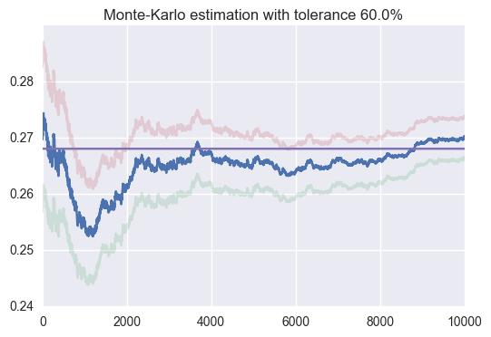

```python
draw_sample_ball(0.4, 0.60, 10000)
draw_expected(0.4, 10000)
```

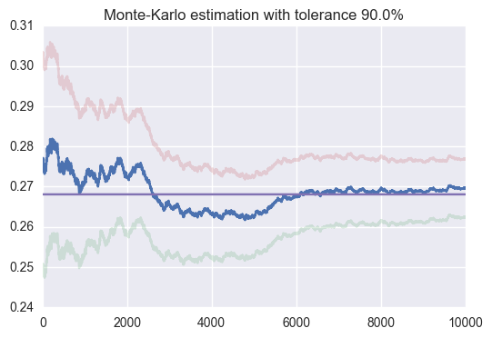

```python
draw_sample_ball(0.4, 0.90, 10000)
draw_expected(0.4, 10000)
```